# GHSA Data Processing

Steph Eaneff Talus Analytics

8/9/2017

# Datasets (Initial Data)

## CRS

CRS data are not currently being used to generate the mock dataset, as the online CRS data exporter tool does not function as expected, and returns partial data plus an error message. Once exported, the data include only net disbursements, but not commitments. An error message is generated.

## Bill and Melinda Gates Foundation

### Details

**Subdirectory:** gates_foundation  
**Source:** Bill and Melinda Gates Grants Database, 2017 Global Health Funding  
**Dataset:** custom export using 2017 data for program == “Global Health”  
**Dataset details:** grantee, year, issue, program, amount  
**Brief description:** Bill and Melinda Gates Foundation data for grants given in 2017 for “Global Health” purposes  
**General Location: https://www.gatesfoundation.org/How-We-Work/Quick-Links/Grants-Database**  
Data Obtained Date:** 8/14/2017

### Data Processing

- Remove “$” and commas from amount field
- Add Gates Foundation as funder
- Add “Private sector” as funder_type
- Add “Gates Foundation” as data source

## GAVI

### Details

**Source:** GAVI Vaccine Alliance  
**Dataset:** Commitments and Dispersements for All Countries for 2001-2017 (TOTAL COMMITMENTS - Inception to June 30, 2017)  
**Brief description:** GAVI provides information regarding all of its funding commitments and dispersements for vaccine-related initiatives.  
**Level of aggregation:** Funder (always GAVI), Recipient, Program, Year  
**Location:** http://www.gavi.org/results/disbursements/  
**Data Obtained Date:** 8/8/2017

### Data Processing

- Exclude Total Counts and only look at item-level information (avoid double counting)
- Populate empty fields caused by merges in Microsoft Excel
- Format dollars to appear as numers (exclude commas)
- Add “GAVI” as data source
- Add “GAVI” as channel
- Add “Immunization” as core capability
- Add “Prevent” as core element
- Add “Public-Private partnership” as funder type

## G-Finder

### Details

**Source:** Policy Cures G-Finder  
**Dataset:** Neglected Disease Funding for all diseases - all products for FYI 2015  
**Brief description:** The G-Finder database provides information on funding for 35 neglected diseases across 142 product areas including drugs, vaccines, diagnostics, microbicides, and vector control products. Data are collected by survey and manually collated and reviewed by the Policy Cures team.  
**Level of aggregation:** Disease, Secondary-level Disease, Product, Funder, Funding Type, Recipeint, Year  
**Location:** https://gfinder.policycuresresearch.org/PublicSearchTool/  
**Data Obtained Date:** 8/8/2017  
**Note:** It’s possible to export data for long periods than just one year, but selecting especially long time periods caused the data exporter tool to return an error and no data.

### Data Processing

- Format dollars to appear as numers (exclude commas)
- Remove the string “FY”" from the beginning of printed years
- Add “G-Finder” as data source

## IHME

### Details

**Source:** IHME (Institute for Health Metrics and Evaluation, University of Washington)  
**Dataset:** Development Assistance for Health Database 1990-2016  
**Brief description:** Information on global health assistance during the timeframe specified, based on data obtained from project databases, financial statements, annual reports, IRS 990s, and correspondence with agencies.  
**Level of aggregation:** Funder, country, geographic region, health focus area  
**Location:** http://ghdx.healthdata.org/record/development-assistance-health-database-1990-2016  
**Data Obtained Date:** 8/7/2017

### Data Processing

- Exclude preliminary estimates and duplicated entries that could cause double-counting
- Add “IHME” as data source
- Restructure dataset from wide to long, so that we have one row per year-funder-recipient-purpose, as opposed to the original structure of one row per year-funder-recipient with individual columns corresponding to purpose.

## OIE

### Details

**Source:** OIE (World Organization for Animal Health)  
**Dataset:** OIE Procurement Contracts, Grants and Sub-Grants awarded by the OIE with funding by the European Union (EU)  
**Brief description:** All active contribution agreements signed between the OIE and the EU in support of OIE programs, project, and activities. EU Only.  
**Level of aggregation:** Funder (always EU), Recipient, Program, Year  
**Location:** http://www.oie.int/fileadmin/Home/eng/Support_to_OIE_Members/pdf/EU_Procurement-contracts-and-Grants-published_SEP-2016_01.pdf  
**Data Obtained Date:** 8/8/2017  
**Note:** Data manually extracted from pdf

### Data Processing

- Extract year from field Date.of.Signature.of.Contract
- Add “OIE” as channel
- Add “OIE” as data source

## Aggregate Data

### Map Equivalent Fields Together

Since each dataset (GAVI, G-Finder, OIE, and IHME) each had unique data structures and variable (“field”) names, it was necessary to develop a mapping of equivalent fields. The datatable printed below shows the way in which fields in each datasource were mapped to a standardized data ontology including broad categories like year, amount, funder, and disease.

Across sources, data are reported at varying levels of resolution. For instance, G-Finder reports disease information at a much higher level of resolution (e.g. “Strongyloidiasis & other intestinal roundworms”) than IHME (e.g. “infectious disease”).

| source | fieldname | standard_fieldname | currency | variable_description |
| --- | --- | --- | --- | --- |
| IHME | disease | application_area_notes |  | Disease or application area (e.g. malaria, newborn and child health, etc) |
| IHME | product | core_capability_notes |  | Product being developed (e.g. vaccines, diagnostics, treatments) |
| IHME | data_source | data_source |  | Data Source |
| G-Finder | Disease | application_area_notes |  | Disease Category (e.g. TB, Leprosy, Helminths, Filoviral diseases, etc) |
| G-Finder | Secondary.level.disease |  |  | More specific disease information |
| G-Finder | Product | core_capability_notes |  | Product being developed (e.g. basic research, diagnostics) |
| G-Finder | Funder | funder |  | Agency of funder |
| G-Finder | Type.of.Funder | funder_type |  | Type of funder (e.g. Philanthropic, Private sector, Public sector - Governments) |
| G-Finder | Funder.country | funder_country |  | Country of funder |
| G-Finder | Funding.type |  |  | Distribution mechanism (e.g. funding to research and developers or self-funding) |

[output cut: 45 more lines]

## Overall Data Processing

### Application Area/Disease

(Semi)-manually map application area notes to application areas. Note that we may want to update these application areas in the future.

### Core Element and Core Capacity

#### Funder Country

```
## [1] "Full dataset has 1,135,278 rows and is 98.695869 MB"
```

# Demo Data

## Sampled Actual Data

The sampled dataset used as part of the demo dataset will include data from the following sources:  
* GAVI (random sample of 25 recipient-application pairs form years 2012-2015) * OIE (all data from 2012-2015) * G-Finder (random sample of 100 committed funds from 2015 only) * Gates Foundation (random sample of 100 committed funds from 2017 only)

#### Recipient

Only a single recipient example needs to be recoded.

## Simulated Data

Generate simulated dataset, drawing from actual distribution of dispersals reported in IHME, G-Finder, GAVI, and OIE databases.

## Demo Dataset

| project_name | application_area | core_element | core_capability | funder | funder_type | funder_country | channel | recipient | recipient_type | recipient_country | amount_committed | amount_dispersed | year | data_source | row_id |
| --- | --- | --- | --- | --- | --- | --- | --- | --- | --- | --- | --- | --- | --- | --- | --- |
|  | nonspecific | Prevent | Immunization | GAVI | Public-Private partnership |  | GAVI | Zimbabwe | Public sector | Zimbabwe | 323000 | 323000 | 2013 | GAVI | 2209 |
|  | Infectious Disease, other | Prevent | Immunization | GAVI | Public-Private partnership |  | GAVI | Zimbabwe | Public sector | Zimbabwe | 190779 | 191772 | 2013 | GAVI | 2208 |
|  | nonspecific | Prevent | Immunization | GAVI | Public-Private partnership |  | GAVI | Sudan South | Public sector | Sudan South | 312826 | 312826 | 2015 | GAVI | 2846 |
|  | Infectious Disease, other | Prevent | Immunization | GAVI | Public-Private partnership |  | GAVI | Burkina Faso | Public sector | Burkina Faso | 2461500 | 2490636 | 2013 | GAVI | 1967 |
|  | nonspecific | Prevent | Immunization | GAVI | Public-Private partnership |  | GAVI | Cameroun | Public sector | Cameroun | 1203375 | 1203375 | 2015 | GAVI | 2565 |
|  | nonspecific | Prevent | Immunization | GAVI | Public-Private partnership |  | GAVI | Kyrgyz Rep | Public sector | Kyrgyz Rep | 873311 | 305398 | 2015 | GAVI | 2692 |
|  | Infectious Disease, other | Prevent | Immunization | GAVI | Public-Private partnership |  | GAVI | Benin | Public sector | Benin | 1723160 | 1723160 | 2012 | GAVI | 1743 |
|  | Infectious Disease, other | Prevent | Immunization | GAVI | Public-Private partnership |  | GAVI | Togo | Public sector | Togo | 219276 | 219276 | 2014 | GAVI | 2458 |
|  | nonspecific | Prevent | Immunization | GAVI | Public-Private partnership |  | GAVI | Kiribati | Public sector | Kiribati | 14000 | 15742 | 2015 | GAVI | 2686 |
|  | nonspecific | Prevent | Immunization | GAVI | Public-Private partnership |  | GAVI | Cambodia | Public sector | Cambodia | 4852686 | 4852686 | 2015 | GAVI | 2552 |

[output cut: 396 more lines]

# Analysis Ideas

## Sanity Checks of Data Generation (Notional Data)

The straighforward analyses included below are inteded to confirm that the demo dataset is functioning as expected, and to brainstorm potential visualizations for future web development.

### Data Source

Check that simulated notional data isn’t too far out of line, compared to actual data. Note that since simulated data is based samples from actual data, this shouldn’t be the case.

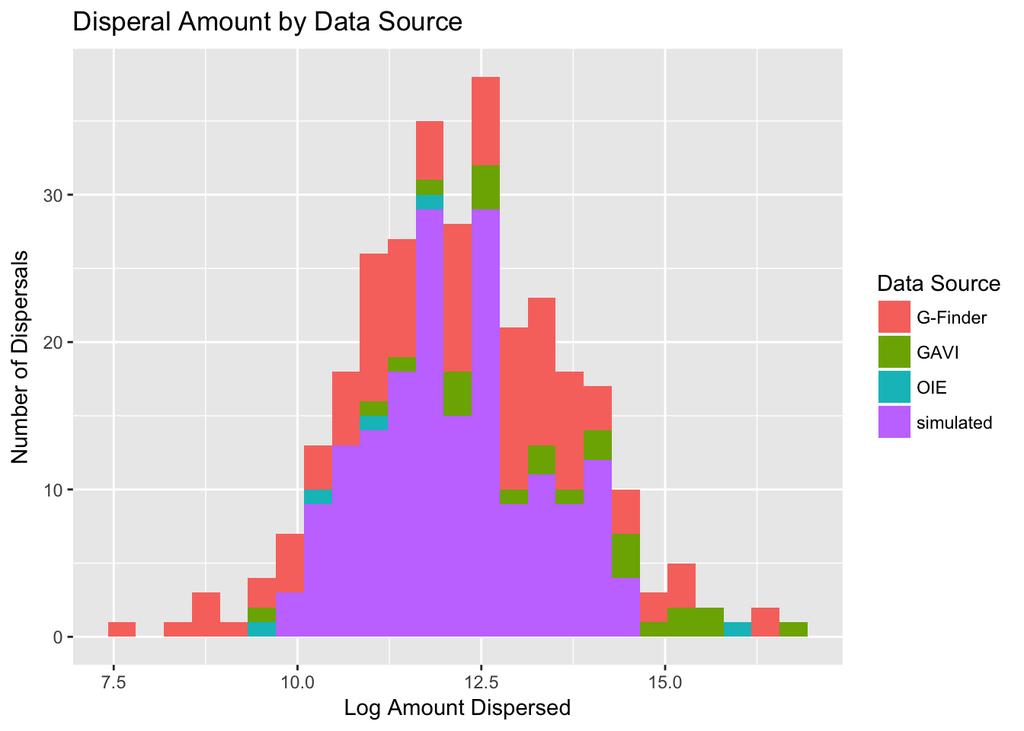

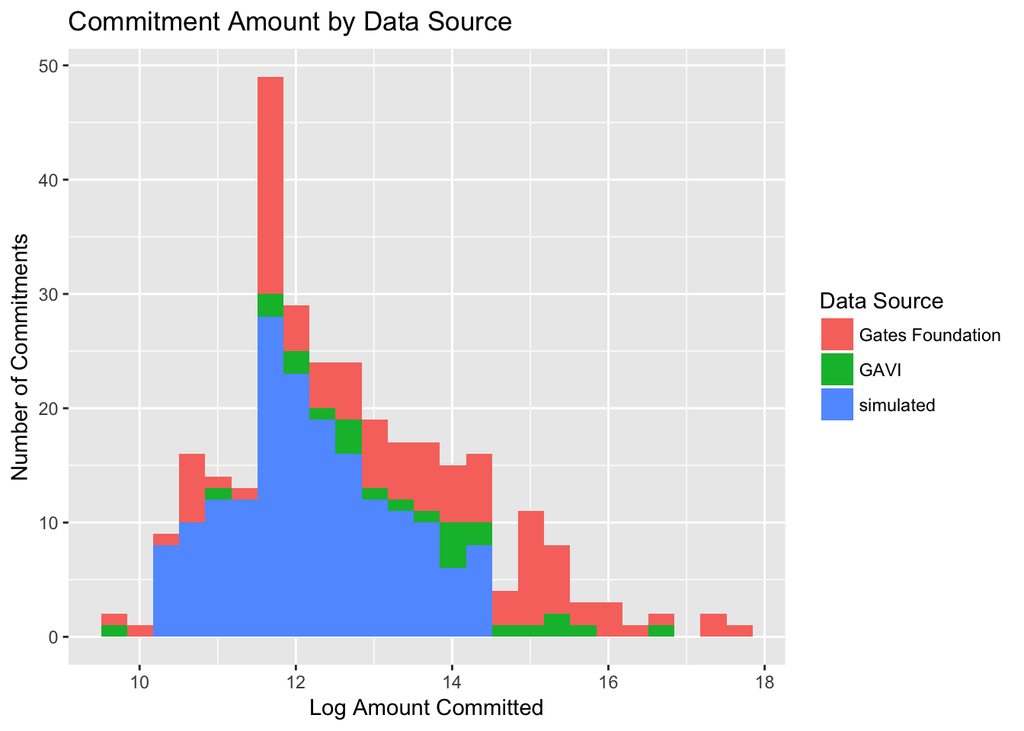

### Amount Dispersed

This should have a legend, but not going to spend the time doing it in R since it’s a decent amount of work for this type of plot (boo ggplot2 for not allowing more manual overrides).

Prevent: red  
Detect: blue  
Respond: green  
Other: orange

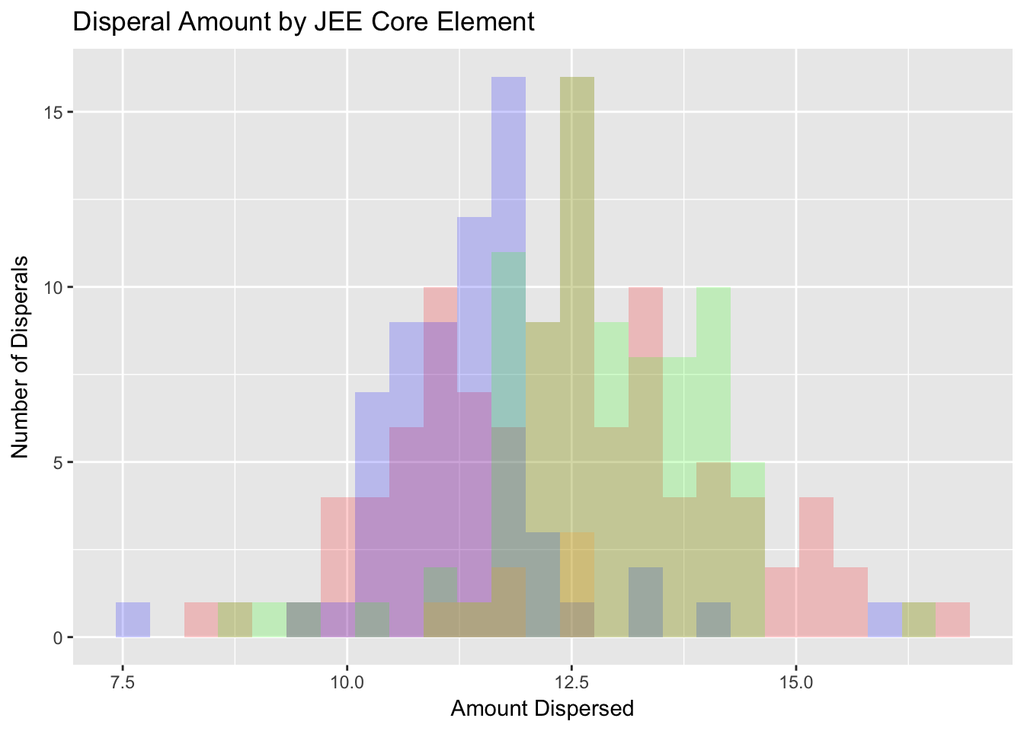

## Analysis Ideas

### Which core elements (prevent, detect, respond) are most funded?

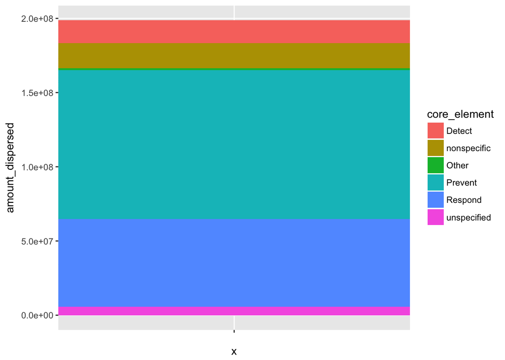

### How has funding for core elements changed over time?

Something like this (https://stackoverflow.com/questions/34244813/100-stacked-area-plot-in-ggplot2) if temporal data are available.

### Where are the most funds being dispersed?

World with country color proportaional to sum of amount_dispersed, grouped by recipient_country. Not going to spend time making this in R since it’s a decent amount of work and will need to be re-done in js anyway.

### Who is dispersing the most funds?

World with country color proportaional to sum of amount_dispersed, grouped by funder_country. Not going to spend time making this in R since it’s a decent amount of work and will need to be re-done in js anyway.